# IODS course project

# About the project

*This is a test*

# Regression and model validation

*Load libraries*

library(ggplot2)

library(GGally)

*Reading the “learning 2014” data into a dataframe*

dta <- read.csv(“./data/learning2014.csv”, sep = “,”, header = TRUE)

*check the dataframe dimensions and structure*

*plotting the data into a graph*

p <- ggpairs(dta, mapping = aes(col = gender, alpha = 0.3), lower = list(combo = wrap(“facethist”, bins = 20)))

*lets take attitude, age, and gender to a regression model*

my_model <- lm(Points ~ Attitude + Age + gender, data = dta)

my_model <- lm(Points ~ Attitude, data = dta)

par(mfrow=c(2,2))

## Logistic regression

Arto Vesterbacka

This chapter is about logistic regression using student data.

## Data Wrangling

Here we take the student data from two files, combine them into one with only the observations that are found from both sets. We also create new variables from existing ones to be used in later analysis.

### Setting up libraries and working directory.

Here we load all the required libraries for the data wrangling and analysis.

```r
library(knitr)
library(ggplot2)
library(dplyr)
library(tidyr)
library(GGally)
```

### Setting the working directory

Here we set the working directory. If you are going to run this on your computer, you will need to set tis to the correct path corresponding to your system.

```r
setwd("C:/koulu/mooc/intro to open data/IODS-project/") # change this if you wish to run the code on your computer
```

### Loading the data

Loading the data from 2 csv-files, and checking their dimensions and structures

```r
dta_mat <- read.csv("student-mat.csv", sep=";", header=TRUE)
dta_por <- read.csv("student-por.csv", sep=";", header=TRUE)
dim(dta_mat)
```

```
## [1] 395  33
```

```r
dim(dta_por)
```

```
## [1] 649  33
```

```r
str(dta_mat)
```

```
## 'data.frame':    395 obs. of  33 variables:
##  $ school    : Factor w/ 2 levels "GP","MS": 1 1 1 1 1 1 1 1 1 1 ...
##  $ sex       : Factor w/ 2 levels "F","M": 1 1 1 1 1 2 2 1 2 2 ...
##  $ age       : int  18 17 15 15 16 16 16 17 15 15 ...
##  $ address   : Factor w/ 2 levels "R","U": 2 2 2 2 2 2 2 2 2 2 ...
##  $ famsize   : Factor w/ 2 levels "GT3","LE3": 1 1 2 1 1 2 2 1 2 1 ...
##  $ Pstatus   : Factor w/ 2 levels "A","T": 1 2 2 2 2 2 2 1 1 2 ...
##  $ Medu      : int  4 1 1 4 3 4 2 4 3 3 ...
##  $ Fedu      : int  4 1 1 2 3 3 2 4 2 4 ...
##  $ Mjob      : Factor w/ 5 levels "at_home","health",..: 1 1 1 2 3 4 3 3 4 3 ...
##  $ Fjob      : Factor w/ 5 levels "at_home","health",..: 5 3 3 4 3 3 3 5 3 3 ...
##  $ reason    : Factor w/ 4 levels "course","home",..: 1 1 3 2 2 4 2 2 2 2 ...
##  $ guardian  : Factor w/ 3 levels "father","mother",..: 2 1 2 2 1 2 2 2 2 2 ...
##  $ traveltime: int  2 1 1 1 1 1 1 2 1 1 ...
##  $ studytime : int  2 2 2 3 2 2 2 2 2 2 ...
```

[output cut: 19 more lines]

```r
str(dta_por)
```

```
## 'data.frame':    649 obs. of  33 variables:
##  $ school    : Factor w/ 2 levels "GP","MS": 1 1 1 1 1 1 1 1 1 1 ...
##  $ sex       : Factor w/ 2 levels "F","M": 1 1 1 1 1 2 2 1 2 2 ...
##  $ age       : int  18 17 15 15 16 16 16 17 15 15 ...
##  $ address   : Factor w/ 2 levels "R","U": 2 2 2 2 2 2 2 2 2 2 ...
##  $ famsize   : Factor w/ 2 levels "GT3","LE3": 1 1 2 1 1 2 2 1 2 1 ...
##  $ Pstatus   : Factor w/ 2 levels "A","T": 1 2 2 2 2 2 2 1 1 2 ...
##  $ Medu      : int  4 1 1 4 3 4 2 4 3 3 ...
##  $ Fedu      : int  4 1 1 2 3 3 2 4 2 4 ...
##  $ Mjob      : Factor w/ 5 levels "at_home","health",..: 1 1 1 2 3 4 3 3 4 3 ...
##  $ Fjob      : Factor w/ 5 levels "at_home","health",..: 5 3 3 4 3 3 3 5 3 3 ...
##  $ reason    : Factor w/ 4 levels "course","home",..: 1 1 3 2 2 4 2 2 2 2 ...
##  $ guardian  : Factor w/ 3 levels "father","mother",..: 2 1 2 2 1 2 2 2 2 2 ...
##  $ traveltime: int  2 1 1 1 1 1 1 2 1 1 ...
##  $ studytime : int  2 2 2 3 2 2 2 2 2 2 ...
```

[output cut: 19 more lines]

### Joining the two dataset

Joining the two dataset with only the students present in both sets

```r
join_by <- c("school","sex","age","address","famsize","Pstatus","Medu","Fedu","Mjob","Fjob","reason","nursery","internet")
mat <- inner_join(dta_mat, dta_por, by = join_by)
dim(mat)
```

```
## [1] 382  53
```

```r
str(mat)
```

```
## 'data.frame':    382 obs. of  53 variables:
##  $ school      : Factor w/ 2 levels "GP","MS": 1 1 1 1 1 1 1 1 1 1 ...
##  $ sex         : Factor w/ 2 levels "F","M": 1 1 1 1 1 2 2 1 2 2 ...
##  $ age         : int  18 17 15 15 16 16 16 17 15 15 ...
##  $ address     : Factor w/ 2 levels "R","U": 2 2 2 2 2 2 2 2 2 2 ...
##  $ famsize     : Factor w/ 2 levels "GT3","LE3": 1 1 2 1 1 2 2 1 2 1 ...
##  $ Pstatus     : Factor w/ 2 levels "A","T": 1 2 2 2 2 2 2 1 1 2 ...
##  $ Medu        : int  4 1 1 4 3 4 2 4 3 3 ...
##  $ Fedu        : int  4 1 1 2 3 3 2 4 2 4 ...
##  $ Mjob        : Factor w/ 5 levels "at_home","health",..: 1 1 1 2 3 4 3 3 4 3 ...
##  $ Fjob        : Factor w/ 5 levels "at_home","health",..: 5 3 3 4 3 3 3 5 3 3 ...
##  $ reason      : Factor w/ 4 levels "course","home",..: 1 1 3 2 2 4 2 2 2 2 ...
##  $ guardian.x  : Factor w/ 3 levels "father","mother",..: 2 1 2 2 1 2 2 2 2 2 ...
##  $ traveltime.x: int  2 1 1 1 1 1 1 2 1 1 ...
##  $ studytime.x : int  2 2 2 3 2 2 2 2 2 2 ...
```

[output cut: 39 more lines]

### Data concatination

Here we find all the variables from the 2 data sets and combine them by taking the average of the numerical variables, and taking only one of the non-numerical variables

```r
alc <- select(mat, one_of(join_by))

# the columns in the datasets which were not used for joining the data
notjoined_columns <- colnames(dta_mat)[!colnames(dta_mat) %in% join_by]

# for every column name not used for joining...
for(column_name in notjoined_columns) {
  # select two columns from 'math_por' with the same original name
  two_columns <- select(mat, starts_with(column_name, ignore.case = TRUE))
  # select the first column vector of those two columns
  first_column <- select(two_columns, 1)[[1]]

  # if that first column vector is numeric...
  if(is.numeric(first_column)) {
    # take a rounded average of each row of the two columns and
    # add the resulting vector to the alc data frame
    alc[column_name] <- round(rowMeans(two_columns))
  } else { # else if it's not numeric...
    # add the first column vector to the alc data frame
    alc[column_name] <- first_column
  }
}
```

### Mutating columns into one

Here we create new variables from existing ones to be used in the later stages of the analysis

```r
alc <- mutate(alc, alc_use = (Dalc + Walc) / 2)
alc <- mutate(alc, high_use = alc_use > 2)
glimpse(alc)
```

```
## Observations: 382
## Variables: 35
## $ school     <fct> GP, GP, GP, GP, GP, GP, GP, GP, GP, GP, GP, GP, GP,...
## $ sex        <fct> F, F, F, F, F, M, M, F, M, M, F, F, M, M, M, F, F, ...
## $ age        <int> 18, 17, 15, 15, 16, 16, 16, 17, 15, 15, 15, 15, 15,...
## $ address    <fct> U, U, U, U, U, U, U, U, U, U, U, U, U, U, U, U, U, ...
## $ famsize    <fct> GT3, GT3, LE3, GT3, GT3, LE3, LE3, GT3, LE3, GT3, G...
## $ Pstatus    <fct> A, T, T, T, T, T, T, A, A, T, T, T, T, T, A, T, T, ...
## $ Medu       <int> 4, 1, 1, 4, 3, 4, 2, 4, 3, 3, 4, 2, 4, 4, 2, 4, 4, ...
## $ Fedu       <int> 4, 1, 1, 2, 3, 3, 2, 4, 2, 4, 4, 1, 4, 3, 2, 4, 4, ...
## $ Mjob       <fct> at_home, at_home, at_home, health, other, services,...
## $ Fjob       <fct> teacher, other, other, services, other, other, othe...
## $ reason     <fct> course, course, other, home, home, reputation, home...
## $ nursery    <fct> yes, no, yes, yes, yes, yes, yes, yes, yes, yes, ye...
## $ internet   <fct> no, yes, yes, yes, no, yes, yes, no, yes, yes, yes,...
```

[output cut: 22 more lines]

### Save the data

Here we save the data into a csv-file for later usage.

```r
write.csv(x = alc, file="./data/alc_data.csv")
```

## Analysis

### Reading the data from the csv-file

```r
chap3 <- read.table("./data/alc_data.csv", sep=",", header=TRUE)
str(chap3)
```

```
## 'data.frame':    382 obs. of  36 variables:
##  $ X         : int  1 2 3 4 5 6 7 8 9 10 ...
##  $ school    : Factor w/ 2 levels "GP","MS": 1 1 1 1 1 1 1 1 1 1 ...
##  $ sex       : Factor w/ 2 levels "F","M": 1 1 1 1 1 2 2 1 2 2 ...
##  $ age       : int  18 17 15 15 16 16 16 17 15 15 ...
##  $ address   : Factor w/ 2 levels "R","U": 2 2 2 2 2 2 2 2 2 2 ...
##  $ famsize   : Factor w/ 2 levels "GT3","LE3": 1 1 2 1 1 2 2 1 2 1 ...
##  $ Pstatus   : Factor w/ 2 levels "A","T": 1 2 2 2 2 2 2 1 1 2 ...
##  $ Medu      : int  4 1 1 4 3 4 2 4 3 3 ...
##  $ Fedu      : int  4 1 1 2 3 3 2 4 2 4 ...
##  $ Mjob      : Factor w/ 5 levels "at_home","health",..: 1 1 1 2 3 4 3 3 4 3 ...
##  $ Fjob      : Factor w/ 5 levels "at_home","health",..: 5 3 3 4 3 3 3 5 3 3 ...
##  $ reason    : Factor w/ 4 levels "course","home",..: 1 1 3 2 2 4 2 2 2 2 ...
##  $ nursery   : Factor w/ 2 levels "no","yes": 2 1 2 2 2 2 2 2 2 2 ...
##  $ internet  : Factor w/ 2 levels "no","yes": 1 2 2 2 1 2 2 1 2 2 ...
```

[output cut: 22 more lines]

### Selecting 4 interesting variable for analysis on alcohol usage

We select absences, romantic, goout, and internet as the variables to explain high/low alcohol usage

```r
chap3 %>% group_by(sex, high_use, romantic, internet) %>% summarise(count = n(), absens = mean(absences, go_out = mean(goout)))
```

```
## # A tibble: 15 x 6
## # Groups:   sex, high_use, romantic [8]
##    sex   high_use romantic internet count absens
##    <fct> <lgl>    <fct>    <fct>    <int>  <dbl>
##  1 F     FALSE    no       no          22   3.5
##  2 F     FALSE    no       yes         77   3.87
##  3 F     FALSE    yes      no           7   3.43
##  4 F     FALSE    yes      yes         50   5.2
##  5 F     TRUE     no       no           6   3.17
##  6 F     TRUE     no       yes         24   6.25
##  7 F     TRUE     yes      yes         12   9.67
##  8 M     FALSE    no       no          10   2
##  9 M     FALSE    no       yes         71   3.07
## 10 M     FALSE    yes      no           4   0.75
## 11 M     FALSE    yes      yes         27   3.44
## 12 M     TRUE     no       no           7   6.14
## 13 M     TRUE     no       yes         44   5.82
## 14 M     TRUE     yes      no           2   3
## 15 M     TRUE     yes      yes         19   7.16
```

[figure not shown]

```r
par(mfrow=c(2,2))
pair_plot <- ggpairs(chap3, columns = c("sex","absences", "romantic", "goout", "internet"), aes(col = sex, alpha = 0.3), lower = list(combo = wrap("facethist", bins = 20)))
pair_plot
```

### Logistic regression model

Here we will do the logistic regression analysis using our selected variables

```r
model = glm(high_use ~ absences + romantic + goout + internet, data = chap3, family = "binomial")
summary(model)
```

```
##
## Call:
## glm(formula = high_use ~ absences + romantic + goout + internet,
##     family = "binomial", data = chap3)
##
## Deviance Residuals:
##     Min       1Q   Median       3Q      Max
## -1.9782  -0.7722  -0.5374   0.9335   2.3816
##
## Coefficients:
##             Estimate Std. Error z value Pr(>|z|)
## (Intercept) -3.51817    0.50441  -6.975 3.06e-12 ***
## absences     0.08037    0.02232   3.601 0.000317 ***
## romanticyes -0.33446    0.27070  -1.236 0.216636
## goout        0.73992    0.11765   6.289 3.20e-10 ***
## internetyes -0.06478    0.34903  -0.186 0.852748
## ---
## Signif. codes:  0 '***' 0.001 '**' 0.01 '*' 0.05 '.' 0.1 ' ' 1
##
## (Dispersion parameter for binomial family taken to be 1)
##
##     Null deviance: 465.68  on 381  degrees of freedom
## Residual deviance: 400.89  on 377  degrees of freedom
## AIC: 410.89
##
## Number of Fisher Scoring iterations: 4
```

```r
OR = coef(model) %>% exp
CI = confint(model) %>% exp
cbind(OR, CI)
```

```
##                     OR      2.5 %     97.5 %
## (Intercept) 0.02965359 0.01057816 0.07678986
## absences    1.08368605 1.03873252 1.13492284
## romanticyes 0.71572655 0.41671077 1.20759317
## goout       2.09576022 1.67322187 2.65641593
## internetyes 0.93726960 0.47979640 1.90015935
```

### Clustering and classification

Here we look at a dataset from Boston on crime.

```r
library(MASS)
```

```r
library(dplyr)
library(ggplot2)
library(corrplot)
data("Boston")
```

```r
str(Boston)
```

```
## 'data.frame':    506 obs. of  14 variables:
##  $ crim   : num  0.00632 0.02731 0.02729 0.03237 0.06905 ...
##  $ zn     : num  18 0 0 0 0 0 12.5 12.5 12.5 12.5 ...
##  $ indus  : num  2.31 7.07 7.07 2.18 2.18 2.18 7.87 7.87 7.87 7.87 ...
##  $ chas   : int  0 0 0 0 0 0 0 0 0 0 ...
##  $ nox    : num  0.538 0.469 0.469 0.458 0.458 0.458 0.524 0.524 0.524 0.524 ...
##  $ rm     : num  6.58 6.42 7.18 7 7.15 ...
##  $ age    : num  65.2 78.9 61.1 45.8 54.2 58.7 66.6 96.1 100 85.9 ...
##  $ dis    : num  4.09 4.97 4.97 6.06 6.06 ...
##  $ rad    : int  1 2 2 3 3 3 5 5 5 5 ...
##  $ tax    : num  296 242 242 222 222 222 311 311 311 311 ...
##  $ ptratio: num  15.3 17.8 17.8 18.7 18.7 18.7 15.2 15.2 15.2 15.2 ...
##  $ black  : num  397 397 393 395 397 ...
##  $ lstat  : num  4.98 9.14 4.03 2.94 5.33 ...
##  $ medv   : num  24 21.6 34.7 33.4 36.2 28.7 22.9 27.1 16.5 18.9 ...
```

```r
summary(Boston)
```

```
##       crim                zn             indus            chas
##  Min.   : 0.00632   Min.   :  0.00   Min.   : 0.46   Min.   :0.00000
##  1st Qu.: 0.08204   1st Qu.:  0.00   1st Qu.: 5.19   1st Qu.:0.00000
##  Median : 0.25651   Median :  0.00   Median : 9.69   Median :0.00000
##  Mean   : 3.61352   Mean   : 11.36   Mean   :11.14   Mean   :0.06917
##  3rd Qu.: 3.67708   3rd Qu.: 12.50   3rd Qu.:18.10   3rd Qu.:0.00000
##  Max.   :88.97620   Max.   :100.00   Max.   :27.74   Max.   :1.00000
##       nox               rm             age              dis
##  Min.   :0.3850   Min.   :3.561   Min.   :  2.90   Min.   : 1.130
##  1st Qu.:0.4490   1st Qu.:5.886   1st Qu.: 45.02   1st Qu.: 2.100
##  Median :0.5380   Median :6.208   Median : 77.50   Median : 3.207
##  Mean   :0.5547   Mean   :6.285   Mean   : 68.57   Mean   : 3.795
##  3rd Qu.:0.6240   3rd Qu.:6.623   3rd Qu.: 94.08   3rd Qu.: 5.188
##  Max.   :0.8710   Max.   :8.780   Max.   :100.00   Max.   :12.127
##       rad              tax           ptratio          black
##  Min.   : 1.000   Min.   :187.0   Min.   :12.60   Min.   :  0.32
##  1st Qu.: 4.000   1st Qu.:279.0   1st Qu.:17.40   1st Qu.:375.38
##  Median : 5.000   Median :330.0   Median :19.05   Median :391.44
##  Mean   : 9.549   Mean   :408.2   Mean   :18.46   Mean   :356.67
##  3rd Qu.:24.000   3rd Qu.:666.0   3rd Qu.:20.20   3rd Qu.:396.23
##  Max.   :24.000   Max.   :711.0   Max.   :22.00   Max.   :396.90
##      lstat            medv
##  Min.   : 1.73   Min.   : 5.00
##  1st Qu.: 6.95   1st Qu.:17.02
##  Median :11.36   Median :21.20
##  Mean   :12.65   Mean   :22.53
##  3rd Qu.:16.95   3rd Qu.:25.00
##  Max.   :37.97   Max.   :50.00
```

```r
head(Boston)
```

```
##      crim zn indus chas   nox    rm  age    dis rad tax ptratio  black
## 1 0.00632 18  2.31    0 0.538 6.575 65.2 4.0900   1 296    15.3 396.90
## 2 0.02731  0  7.07    0 0.469 6.421 78.9 4.9671   2 242    17.8 396.90
## 3 0.02729  0  7.07    0 0.469 7.185 61.1 4.9671   2 242    17.8 392.83
## 4 0.03237  0  2.18    0 0.458 6.998 45.8 6.0622   3 222    18.7 394.63
## 5 0.06905  0  2.18    0 0.458 7.147 54.2 6.0622   3 222    18.7 396.90
## 6 0.02985  0  2.18    0 0.458 6.430 58.7 6.0622   3 222    18.7 394.12
##   lstat medv
## 1  4.98 24.0
## 2  9.14 21.6
## 3  4.03 34.7
## 4  2.94 33.4
## 5  5.33 36.2
## 6  5.21 28.7
```

```r
boston_scaled <- scale(Boston)
boston_scaled <- as.data.frame(boston_scaled)
```

### The dataset

The dataset, Bostin includes 506 observations wiht 14 variables of numerical crime statistics. The dataset consists of crimes per capita, proportions of zoning, non-retail businesses, owner occupied houses built before 1940, and number of African-American individuals. Also includes the median value of houses in k$ and full tax value in 10k$, NO-emissions, status of population, mean distance from centers, pupils per teacher, nr of rooms per dwelling, accessability index and a dummy variable for Charles River.

### EDA

Exploratory data analysis of the data.

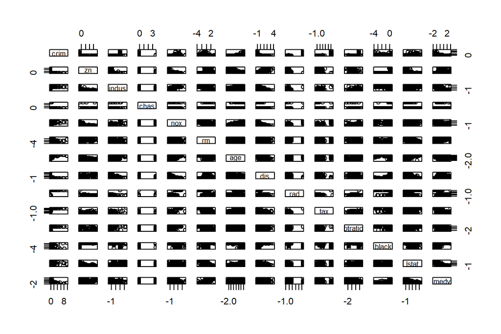

```r
pairs(boston_scaled)
```

```r
# calculate the correlation matrix and round it
cor_matrix<-cor(boston_scaled) %>% round(2)

# print the correlation matrix
cor_matrix
```

```
##          crim    zn indus  chas   nox    rm   age   dis   rad   tax
## crim     1.00 -0.20  0.41 -0.06  0.42 -0.22  0.35 -0.38  0.63  0.58
## zn      -0.20  1.00 -0.53 -0.04 -0.52  0.31 -0.57  0.66 -0.31 -0.31
## indus    0.41 -0.53  1.00  0.06  0.76 -0.39  0.64 -0.71  0.60  0.72
## chas    -0.06 -0.04  0.06  1.00  0.09  0.09  0.09 -0.10 -0.01 -0.04
## nox      0.42 -0.52  0.76  0.09  1.00 -0.30  0.73 -0.77  0.61  0.67
## rm      -0.22  0.31 -0.39  0.09 -0.30  1.00 -0.24  0.21 -0.21 -0.29
## age      0.35 -0.57  0.64  0.09  0.73 -0.24  1.00 -0.75  0.46  0.51
## dis     -0.38  0.66 -0.71 -0.10 -0.77  0.21 -0.75  1.00 -0.49 -0.53
## rad      0.63 -0.31  0.60 -0.01  0.61 -0.21  0.46 -0.49  1.00  0.91
## tax      0.58 -0.31  0.72 -0.04  0.67 -0.29  0.51 -0.53  0.91  1.00
## ptratio  0.29 -0.39  0.38 -0.12  0.19 -0.36  0.26 -0.23  0.46  0.46
## black   -0.39  0.18 -0.36  0.05 -0.38  0.13 -0.27  0.29 -0.44 -0.44
## lstat    0.46 -0.41  0.60 -0.05  0.59 -0.61  0.60 -0.50  0.49  0.54
## medv    -0.39  0.36 -0.48  0.18 -0.43  0.70 -0.38  0.25 -0.38 -0.47
##         ptratio black lstat  medv
## crim       0.29 -0.39  0.46 -0.39
## zn        -0.39  0.18 -0.41  0.36
## indus      0.38 -0.36  0.60 -0.48
## chas      -0.12  0.05 -0.05  0.18
## nox        0.19 -0.38  0.59 -0.43
## rm        -0.36  0.13 -0.61  0.70
## age        0.26 -0.27  0.60 -0.38
## dis       -0.23  0.29 -0.50  0.25
## rad        0.46 -0.44  0.49 -0.38
## tax        0.46 -0.44  0.54 -0.47
## ptratio    1.00 -0.18  0.37 -0.51
## black     -0.18  1.00 -0.37  0.33
## lstat      0.37 -0.37  1.00 -0.74
## medv      -0.51  0.33 -0.74  1.00
```

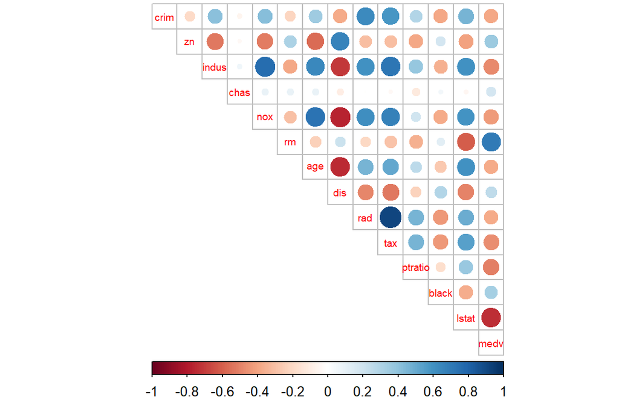

```r
# visualize the correlation matrix
corrplot(cor_matrix, method="circle", type="upper", cl.pos = "b", tl.pos = "d", tl.cex = 0.6)
```

```r
# create a quantile vector of crim and print it
bins <- quantile(boston_scaled$crim)
bins
```

```
##           0%          25%          50%          75%         100%
## -0.419366929 -0.410563278 -0.390280295  0.007389247  9.924109610
```

```r
# create a categorical variable 'crime'
crime <- cut(boston_scaled$crim, breaks = bins, include.lowest = TRUE, labels = c("low", "med_low","med_high","high"))
# remove original crim from the dataset
boston_scaled <- dplyr::select(boston_scaled, -crim)

# add the new categorical value to scaled data
boston_scaled <- data.frame(boston_scaled, crime)
```

### Dividing the data to a training set and test set

```r
# number of rows in the Boston dataset
n <- nrow(boston_scaled)

# choose randomly 80% of the rows
ind <- sample(n,  size = n * 0.8)

# create train set
train <- boston_scaled[ind,]

# create test set
test <- boston_scaled[-ind,]
# save the correct classes from test data
correct_classes <- test$crime
# remove the crime variable from test data
test <- dplyr::select(test, -crime)
```

### Linear discriminant analysis

```r
# linear discriminant analysis
lda.fit <- lda(crime ~ ., data = train)

# print the lda.fit object
lda.fit
```

```
## Call:
## lda(crime ~ ., data = train)
##
## Prior probabilities of groups:
##       low   med_low  med_high      high
## 0.2648515 0.2301980 0.2500000 0.2549505
##
## Group means:
##                  zn      indus        chas        nox          rm
## low       0.9806005 -0.9131098 -0.12514775 -0.8755262  0.43478459
## med_low  -0.1004239 -0.2869541 -0.06065701 -0.5629444 -0.13608105
## med_high -0.3845049  0.2817673  0.19544522  0.5129854  0.05767583
## high     -0.4872402  1.0170891 -0.04298342  1.0826121 -0.43833815
##                 age        dis        rad        tax     ptratio
## low      -0.9165605  0.8927409 -0.6813378 -0.7232316 -0.41762332
## med_low  -0.3331237  0.3500356 -0.5545921 -0.5155085 -0.08078191
## med_high  0.5003931 -0.4503667 -0.4417506 -0.2904406 -0.38008362
## high      0.8059045 -0.8680391  1.6384176  1.5142626  0.78111358
##                black       lstat         medv
## low       0.37596966 -0.76674871  0.499435676
## med_low   0.32228963 -0.13962094 -0.002047148
## med_high  0.08641489  0.04217779  0.129707812
## high     -0.78049938  0.89545645 -0.652462713
##
## Coefficients of linear discriminants:
##                 LD1         LD2         LD3
## zn       0.07006332  0.60412438 -1.02883234
## indus    0.03574773 -0.24620797  0.41701767
## chas    -0.10437493 -0.02373665  0.06004994
## nox      0.29978127 -0.70242356 -1.36680811
## rm      -0.13697453 -0.06203492 -0.18189490
## age      0.30294398 -0.43447468 -0.06156512
## dis     -0.09226294 -0.21082405  0.25368935
## rad      3.35562128  1.03402700  0.19001182
## tax      0.11395107 -0.13613323  0.21196650
## ptratio  0.07780884  0.11644207 -0.32316160
## black   -0.11555865  0.04129097  0.14127537
## lstat    0.19090135 -0.08923245  0.37774580
## medv     0.20818035 -0.28787447 -0.11619365
##
## Proportion of trace:
##    LD1    LD2    LD3
## 0.9481 0.0403 0.0117
```

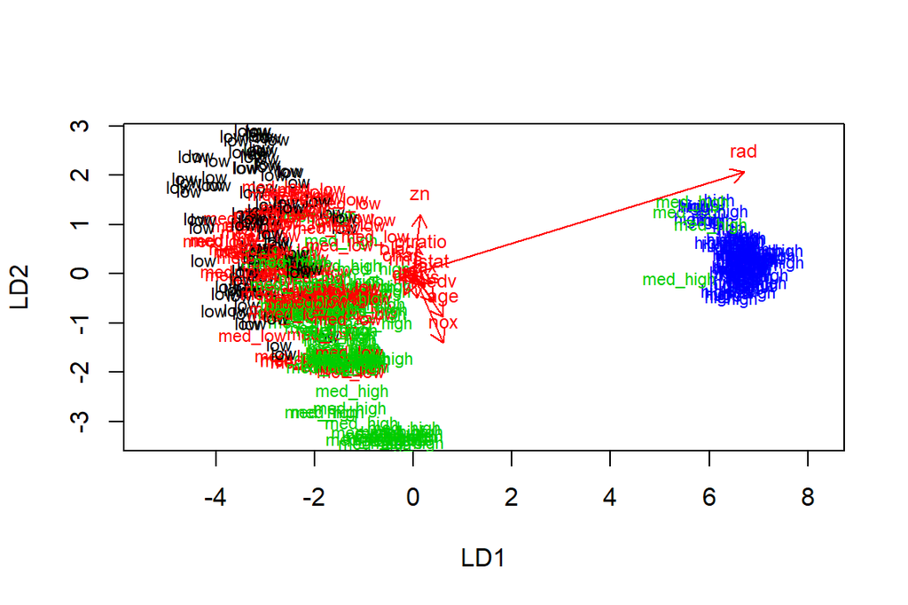

```r
# the function for lda biplot arrows
lda.arrows <- function(x, myscale = 1, arrow_heads = 0.1, color = "red", tex = 0.75, choices = c(1,2)){
  heads <- coef(x)
  arrows(x0 = 0, y0 = 0,
         x1 = myscale * heads[,choices[1]],
         y1 = myscale * heads[,choices[2]], col=color, length = arrow_heads)
  text(myscale * heads[,choices], labels = row.names(heads),
       cex = tex, col=color, pos=3)
}

# target classes as numeric
classes <- as.numeric(train$crime)

# plot the lda results
plot(lda.fit, dimen = 2, col = classes, pch = classes)
lda.arrows(lda.fit, myscale = 2)
```

### Testing the model

```r
# predict classes with test data
lda.pred <- predict(lda.fit, newdata = test)

# cross tabulate the results
table(correct = correct_classes, predicted = lda.pred$class)
```

```
##           predicted
## correct    low med_low med_high high
##   low        9      10        1    0
##   med_low    5      18       10    0
##   med_high   2      11       10    2
##   high       0       0        0   24
```

### K-means clustering

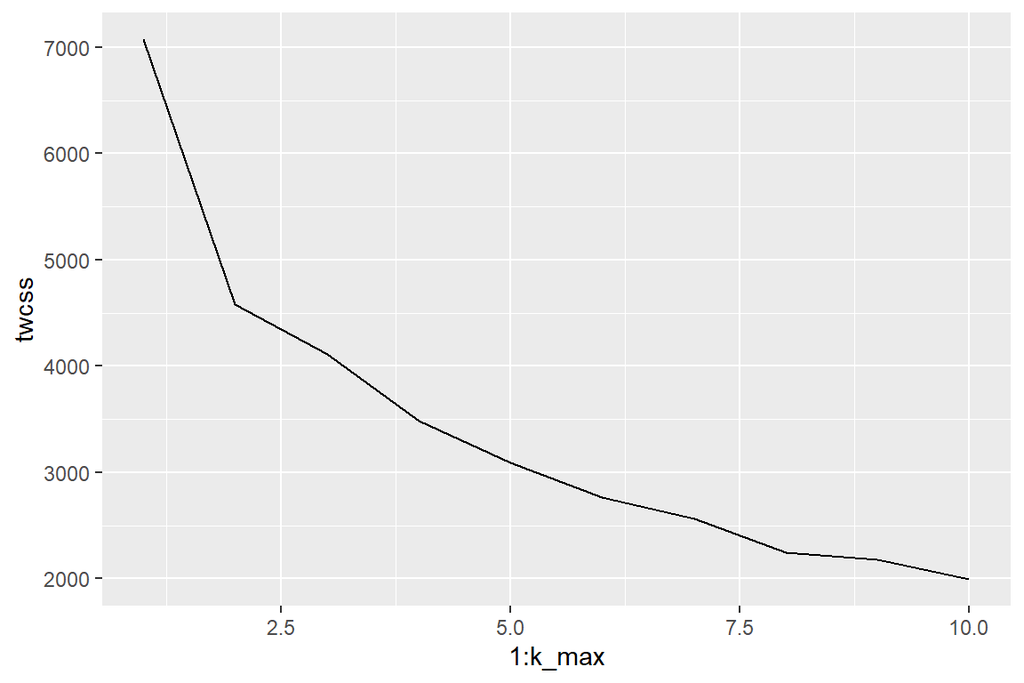

```r
data('Boston')
boston_scaled <- scale(Boston)
dist_eu <- dist(boston_scaled)
k_max <- 10

# calculate the total within sum of squares
twcss <- sapply(1:k_max, function(k){kmeans(boston_scaled, k)$tot.withinss})

# visualize the results
qplot(x = 1:k_max, y = twcss, geom = 'line')
```

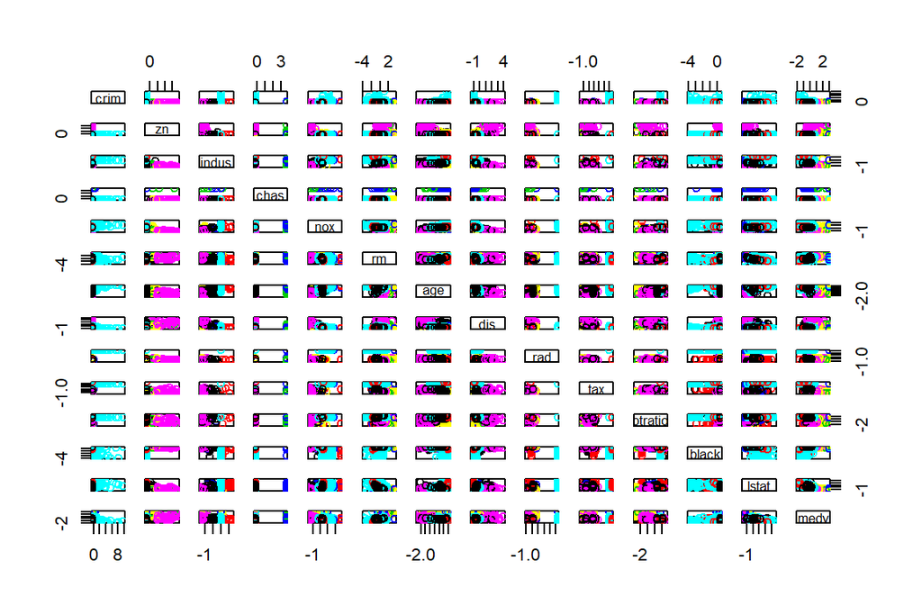

```r
km <-kmeans(boston_scaled, centers = 7)

# plot the Boston dataset with clusters
pairs(boston_scaled, col = km$cluster)
```